# Question 1

## Thyriod Dataset

I chose this dataset because machine learning models can be highly benefitial in the healthcare industry. I wanted to try working with a dataset that I wasn't the most familiar with to challenge my understanding of the algorithms we've learnt and apply it on unfamiliar dataset.

### Attributes

1. Age: Age group intervals
2. Sex: Gender groups
3. On Thyroxine: On thyroxine status
4. On anti-thyroid med: Anti-thyroid medication
5. Query on thyroxine: if thyroxine is present in the body
6. Sick: Current sick status
7. Pregnant: Pregnant status
8. Thyroid surgery: Had thyroid surgery
9. I131: Had I131 treatment
10. Query hypothyroid: Hypothyroidism statue
11. Query hyperthyroid: Hyperthyroidism status
12. Lithium: Lithium status
13. Goiter: Goiter status
14. Tumor: Tumor status
15. Hypopituitary: Hypopituitary status
16. Psych: Psych status
17. TSH measured: if TSH was measured
18. TSH: TSH level intervals (TSH=Normal (0.27≤ TSH ≤4.2); TSH=Abnormal (Not within the normal range))
19. T3 measured: if T3 levels were measured
20. T3: T3 level intervals (T3=Normal (1.3≤ T3 ≤ 3.1), T3=Abnormal (Not within the normal range))
21. TT4 measured: if TT4 was measured
22. TT4: TT4 level intervals (TT4=Normal (62≤ TT4 ≤ 164), TT4=Abnormal (Not within the normal range))
23. T4U: if T4U was measured
24. T4U: T4U level intervals (T4U=Normal (0.7≤ T4U ≤ 1.8), T4U=Abnormal (Not within the normal range))
25. FTI measured: if FTI was measured
26. FTI: FTI level intervals (FTI=Normal (53≤ FTI ≤142), FTI=Abnormal (Not within the normal range))
27. TBG measured: if TBG was measured
28. TBG: TBG levels
29. binaryClass: Thyroid disease status (Negative (Does not have thyroid disease), Positive (Has thyroid disease))

# Question 2

### Research Question

How accurately can we predict thyroid disease diagnosis based on a patient's health data?

Human body works in complex ways. There are numerous anatominal processess that play a part in disease diagnosis. **My aim is to use supervised learning to understand how we can accurately predict thyriod diagnosis based on patient's health data.**

# Question 3

1. A decision tree algorithm provides a natural way to measure feature importance in a dataset. It automatically selects the most informative attributes for splitting nodes in the tree, disregarding irrelevant or redundant features, which simplifies the model and improves generalization performance.
2. Decision trees are highly interpretable. In a medical context it becomes very important to know and be able to explain to patients what aspects/factors lead to certain diseases, so they can make adequate lifestyle changes and treat the disease. For instance, if I were to use neural network to solve this problem, the hidden layers would obscure the decision making that went into the final outcome of the model. Therefore, a model like a decision tree helps us better interpret and answer the research question.

# Question 4

```python
import math
import pandas as pd
import seaborn as sns
import matplotlib.pyplot as plt
import numpy as np
```

```python
# Reading the dataset
df = pd.read_csv("/Users/sadafbandeali/Desktop/UW/Winter'24/IMT 574/Final/hypothyroid_1.csv",sep=',')
df
```

|  | age | sex | on thyroxine | query on thyroxine | on antithyroid medication | sick | pregnant | thyroid surgery | I131 treatment | query hypothyroid | ... | TT4 measured | TT4 | T4U measured | T4U | FTI measured | FTI | TBG measured | TBG | referral source | binaryClass |
| --- | --- | --- | --- | --- | --- | --- | --- | --- | --- | --- | --- | --- | --- | --- | --- | --- | --- | --- | --- | --- | --- |
| 0 | 41 | F | f | f | f | f | f | f | f | f | ... | t | 125 | t | 1.14 | t | 109 | f | ? | SVHC | N |
| 1 | 23 | F | f | f | f | f | f | f | f | f | ... | t | 102 | f | ? | f | ? | f | ? | other | N |
| 2 | 46 | M | f | f | f | f | f | f | f | f | ... | t | 109 | t | 0.91 | t | 120 | f | ? | other | N |
| 3 | 70 | F | t | f | f | f | f | f | f | f | ... | t | 175 | f | ? | f | ? | f | ? | other | N |
| 4 | 70 | F | f | f | f | f | f | f | f | f | ... | t | 61 | t | 0.87 | t | 70 | f | ? | SVI | N |
| ... | ... | ... | ... | ... | ... | ... | ... | ... | ... | ... | ... | ... | ... | ... | ... | ... | ... | ... | ... | ... | ... |
| 3767 | 30 | F | f | f | f | f | f | f | f | f | ... | f | ? | f | ? | f | ? | f | ? | other | N |
| 3768 | 68 | F | f | f | f | f | f | f | f | f | ... | t | 124 | t | 1.08 | t | 114 | f | ? | SVI | N |
| 3769 | 74 | F | f | f | f | f | f | f | f | f | ... | t | 112 | t | 1.07 | t | 105 | f | ? | other | N |
| 3770 | 72 | M | f | f | f | f | f | f | f | f | ... | t | 82 | t | 0.94 | t | 87 | f | ? | SVI | N |
| 3771 | 64 | F | f | f | f | f | f | f | f | f | ... | t | 99 | t | 1.07 | t | 92 | f | ? | other | N |

3772 rows × 30 columns

```python
# Cleaning the dataset
df = df.replace('?', np.nan)    # replacing '?' with NaN
df = df.replace('t', True)      # replacing 't' with True
df = df.replace('f', False)     # replacing 'f' with False
df.info()
```

```
<class 'pandas.core.frame.DataFrame'>
RangeIndex: 3772 entries, 0 to 3771
Data columns (total 30 columns):
 #   Column                     Non-Null Count  Dtype
---  ------                     --------------  -----
 0   age                        3771 non-null   object
 1   sex                        3622 non-null   object
 2   on thyroxine               3772 non-null   bool
 3   query on thyroxine         3772 non-null   bool
 4   on antithyroid medication  3772 non-null   bool
 5   sick                       3772 non-null   bool
 6   pregnant                   3772 non-null   bool
 7   thyroid surgery            3772 non-null   bool
 8   I131 treatment             3772 non-null   bool
 9   query hypothyroid          3772 non-null   bool
```

[output cut: 22 more lines]

```python
# Cleaning the dataset
df_cleaned = df.drop(columns=['TBG', 'TBG measured', 'referral source'])  # dropping the columns that are all False
df_cleaned = df_cleaned.drop(columns=['T3 measured', 'TT4 measured', 'T4U measured', 'FTI measured', 'TSH measured'])  # dropping the columns that are all False
df_cleaned = df_cleaned.dropna()
df_cleaned = df_cleaned.replace({'binaryClass': {'P': True, 'N': False}, 'sex': {'F': True, 'M': False}}) # converting columns into categorical values

df_cleaned
```

|  | age | sex | on thyroxine | query on thyroxine | on antithyroid medication | sick | pregnant | thyroid surgery | I131 treatment | query hypothyroid | ... | goitre | tumor | hypopituitary | psych | TSH | T3 | TT4 | T4U | FTI | binaryClass |
| --- | --- | --- | --- | --- | --- | --- | --- | --- | --- | --- | --- | --- | --- | --- | --- | --- | --- | --- | --- | --- | --- |
| 0 | 41 | True | False | False | False | False | False | False | False | False | ... | False | False | False | False | 1.3 | 2.5 | 125 | 1.14 | 109 | False |
| 4 | 70 | True | False | False | False | False | False | False | False | False | ... | False | False | False | False | 0.72 | 1.2 | 61 | 0.87 | 70 | False |
| 7 | 80 | True | False | False | False | False | False | False | False | False | ... | False | False | False | False | 2.2 | 0.6 | 80 | 0.7 | 115 | False |
| 8 | 66 | True | False | False | False | False | False | False | False | False | ... | False | True | False | False | 0.6 | 2.2 | 123 | 0.93 | 132 | False |
| 9 | 68 | False | False | False | False | False | False | False | False | False | ... | False | False | False | False | 2.4 | 1.6 | 83 | 0.89 | 93 | False |
| ... | ... | ... | ... | ... | ... | ... | ... | ... | ... | ... | ... | ... | ... | ... | ... | ... | ... | ... | ... | ... | ... |
| 3766 | 19 | True | False | False | False | False | False | False | False | False | ... | False | False | False | False | 8.8 | 2.7 | 108 | 1.11 | 97 | True |
| 3768 | 68 | True | False | False | False | False | False | False | False | False | ... | False | False | False | False | 1 | 2.1 | 124 | 1.08 | 114 | False |
| 3769 | 74 | True | False | False | False | False | False | False | False | False | ... | False | False | False | False | 5.1 | 1.8 | 112 | 1.07 | 105 | False |
| 3770 | 72 | False | False | False | False | False | False | False | False | False | ... | False | False | False | False | 0.7 | 2 | 82 | 0.94 | 87 | False |
| 3771 | 64 | True | False | False | False | False | False | False | False | False | ... | False | False | False | False | 1 | 2.2 | 99 | 1.07 | 92 | False |

2643 rows × 22 columns

```python
# Base Model

from sklearn.tree import DecisionTreeClassifier
from sklearn.model_selection import train_test_split
from sklearn.metrics import accuracy_score, precision_score, recall_score
from sklearn.metrics import f1_score

# Defining independent and target variable
X = df_cleaned.drop(columns = ['binaryClass'])
y = df_cleaned['binaryClass']

#  Training and testing
X_train, X_test, y_train, y_test = train_test_split(X, y, test_size=0.2, random_state= 15)

# Creating a Decision Tree classifier
dt_classifier = DecisionTreeClassifier(random_state=67, criterion="gini", max_depth=2)
dt_classifier.fit(X_train, y_train)

print(dt_classifier.feature_importances_)

# Predicting
y_pred_train = dt_classifier.predict(X_train)
y_pred = dt_classifier.predict(X_test)
print("Training Accuracy:", accuracy_score(y_train, y_pred_train))

# Calculating accuracy, precision, and recall for Decision Tree Classifier
accuracy = round(accuracy_score(y_test, y_pred), 4)
print("Accuracy of Model 1(Decision Tree):", accuracy)
precision = round(precision_score(y_test, y_pred), 4)
print("Precision of Model 1(Decision Tree):", precision)
recall = round(recall_score(y_test, y_pred), 4)
print("Recall of Model 1(Decision Tree):", recall)
f1 = f1_score(y_test,y_pred)
print("F1 score of Model 1(Decision Tree):",f1)
```

```
[0.         0.         0.11697083 0.         0.         0.
 0.         0.         0.         0.         0.         0.
 0.         0.         0.         0.         0.8818574  0.
 0.         0.         0.00117177]
Training Accuracy: 0.9900662251655629
Accuracy of Model 1(Decision Tree): 0.9924
Precision of Model 1(Decision Tree): 0.9302
Recall of Model 1(Decision Tree): 0.9756
F1 score of Model 1(Decision Tree): 0.9523809523809524
```

**About Cleaning Dataframe 1:** In the first model, I used a dataframe that was only cleaned for the redundant variables like 'TBG' (which only has NAs and 'TBG measured', its accompanying column. Another variable called 'referral source' also did not have any relevant information. Subsequently, 'T3 measured', 'TT4 measured', 'T4U measured', 'FTI measured', 'TSH measured' all have information that have already been captured in our dataset, so I am dropping those too.

# Question 5

```python
# Categorical Model

# Converting to float to be able to use range filtering later
df_cleaned_with_ranges = df_cleaned.copy()
df_cleaned_with_ranges['TSH'] = df_cleaned_with_ranges['TSH'].astype(float)
df_cleaned_with_ranges['T3'] = df_cleaned_with_ranges['T3'].astype(float)
df_cleaned_with_ranges['TT4'] = df_cleaned_with_ranges['TT4'].astype(float)
df_cleaned_with_ranges['T4U'] = df_cleaned_with_ranges['T4U'].astype(float)
df_cleaned_with_ranges['FTI'] = df_cleaned_with_ranges['FTI'].astype(float)


# categorizing ranges of different tests where true = abnormal range and false = normal range
df_cleaned_with_ranges.loc[(df_cleaned_with_ranges['TSH']>=0.27) & (df_cleaned_with_ranges['TSH']<=4.2),'TSH']= False
df_cleaned_with_ranges.loc[(df_cleaned_with_ranges['TSH']<0.27) | (df_cleaned_with_ranges['TSH']>4.2),'TSH']= True

df_cleaned_with_ranges.loc[(df_cleaned_with_ranges['T3']>=1.3) & (df_cleaned_with_ranges['T3']<=3.1),'T3']= False
df_cleaned_with_ranges.loc[(df_cleaned_with_ranges['T3']<1.3) | (df_cleaned_with_ranges['T3']>3.1),'T3']= True

df_cleaned_with_ranges.loc[(df_cleaned_with_ranges['TT4']>=62) & (df_cleaned_with_ranges['TT4']<=164),'TT4']= False
df_cleaned_with_ranges.loc[(df_cleaned_with_ranges['TT4']<62) | (df_cleaned_with_ranges['TT4']>164),'TT4']= True

df_cleaned_with_ranges.loc[(df_cleaned_with_ranges['T4U']>=0.7) & (df_cleaned_with_ranges['T4U']<=1.8),'T4U']= False
df_cleaned_with_ranges.loc[(df_cleaned_with_ranges['T4U']<0.7) | (df_cleaned_with_ranges['T4U']>1.8),'T4U']= True

df_cleaned_with_ranges.loc[(df_cleaned_with_ranges['FTI']>=53) & (df_cleaned_with_ranges['FTI']<=142),'FTI']= False
df_cleaned_with_ranges.loc[(df_cleaned_with_ranges['FTI']<53) | (df_cleaned_with_ranges['FTI']>142),'FTI']= True


# Cleaning the dataframe and dropping columns which are highly skewed
df_cleaned_with_ranges = df_cleaned_with_ranges.drop(columns=['FTI', 'TT4', 'T3'])

# Defining independent and target variable
X_with_ranges = df_cleaned_with_ranges.drop(columns = ['binaryClass'])
y_with_ranges = df_cleaned_with_ranges['binaryClass']

#  Training and testing
X_train, X_test, y_train, y_test = train_test_split(X_with_ranges, y_with_ranges, test_size=0.2, random_state= 15)

# Creating a Decision Tree classifier
dt_classifier = DecisionTreeClassifier(random_state= 67, criterion="gini", max_depth=10)
dt_classifier.fit(X_train, y_train)


# Predicting
y_pred_train = dt_classifier.predict(X_train)
y_pred = dt_classifier.predict(X_test)

print("[Categorical Model] Feature Importance:", dt_classifier.feature_importances_)
print("[Categorical Model] Training Accuracy:", round(accuracy_score(y_train, y_pred_train),4))
print("[Categorical Model] Accuracy:", round(accuracy_score(y_test, y_pred), 4))
print("[Categorical Model] Precision:", round(precision_score(y_test, y_pred), 4))
print("[Categorical Model] Recall:", round(recall_score(y_test, y_pred), 4))
print("[Categorical Model] F1 Score:", round(f1_score(y_test,y_pred),4))
```

```
[Categorical Model] Feature Importance: [6.25527899e-01 2.90941534e-02 4.80368850e-02 3.64710738e-03
 1.62093661e-03 1.16878983e-02 1.57860155e-02 0.00000000e+00
 0.00000000e+00 8.17743373e-02 1.35472065e-01 0.00000000e+00
 0.00000000e+00 2.00390515e-04 0.00000000e+00 4.71523116e-02
 0.00000000e+00 0.00000000e+00]
[Categorical Model] Training Accuracy: 0.9248
[Categorical Model] Accuracy: 0.9206
[Categorical Model] Precision: 0.3333
[Categorical Model] Recall: 0.0244
[Categorical Model] F1 Score: 0.0455
```

```python
# Entropy and Log Loss Models

#  Training and testing
X_train, X_test, y_train, y_test = train_test_split(X, y, test_size=0.2, random_state= 15)

# Creating a Decision Tree classifier
dt_classifier_entropy = DecisionTreeClassifier(random_state=67, criterion="entropy", max_depth=2)
dt_classifier_entropy.fit(X_train, y_train)

dt_classifier_log_loss = DecisionTreeClassifier(random_state=67, criterion="log_loss", max_depth=2)
dt_classifier_log_loss.fit(X_train, y_train)


# Predicting
y_pred_train_entropy = dt_classifier_entropy.predict(X_train)
y_pred_entropy = dt_classifier_entropy.predict(X_test)

y_pred_train_logloss = dt_classifier_log_loss.predict(X_train)
y_pred_logloss = dt_classifier_log_loss.predict(X_test)


# Calculating accuracy, precision, and recall for Decision Tree Classifier

print("[Entropy Model] Feature Importance:", dt_classifier_entropy.feature_importances_)
print("[Entropy Model] Training Accuracy:", round(accuracy_score(y_train, y_pred_train_entropy),4))
print("[Entropy Model] Accuracy:", round(accuracy_score(y_test, y_pred_entropy), 4))
print("[Entropy Model] Precision:", round(precision_score(y_test, y_pred_entropy), 4))
print("[Entropy Model] Recall:", round(recall_score(y_test, y_pred_entropy), 4))
print("[Entropy Model] F1 Score:", round(f1_score(y_test,y_pred_entropy),4))

print("[Log-Loss Model] Feature Importance:", dt_classifier_log_loss.feature_importances_)
print("[Log-Loss Model] Training Accuracy:", round(accuracy_score(y_train, y_pred_train_logloss),4))
print("[Log-Loss Model] Accuracy:", round(accuracy_score(y_test, y_pred_logloss), 4))
print("[Log-Loss Model] Precision:", round(precision_score(y_test, y_pred_logloss), 4))
print("[Log-Loss Model] Recall:", round(recall_score(y_test, y_pred_logloss), 4))
print("[Log-Loss Model] F1 Score:", round(f1_score(y_test,y_pred_logloss),4))
```

```
[Entropy Model] Feature Importance: [0.         0.         0.0796284  0.         0.         0.
 0.         0.         0.         0.         0.         0.
 0.         0.         0.         0.         0.90945718 0.
 0.         0.         0.01091443]
[Entropy Model] Training Accuracy: 0.9901
[Entropy Model] Accuracy: 0.9924
[Entropy Model] Precision: 0.9302
[Entropy Model] Recall: 0.9756
[Entropy Model] F1 Score: 0.9524
[Log-Loss Model] Feature Importance: [0.         0.         0.0796284  0.         0.         0.
 0.         0.         0.         0.         0.         0.
 0.         0.         0.         0.         0.90945718 0.
 0.         0.         0.01091443]
[Log-Loss Model] Training Accuracy: 0.9901
[Log-Loss Model] Accuracy: 0.9924
[Log-Loss Model] Precision: 0.9302
[Log-Loss Model] Recall: 0.9756
[Log-Loss Model] F1 Score: 0.9524
```

# Question 6

**Changing the dataset structure to use categorical data instead of numerical data**

Base Model. Parameters (Max Depth: 2, Criterion: gini, Data Type: Numerical). Results (Accuracy: 0.9924, Recall: 0.9756, F1 score: 0.9523)

**Changing the criterion for the decision tree**

Base Model. Parameters (Max Depth: 2, Criterion: gini, Data Type: Numerical). Results (Accuracy: 0.9924, Recall: 0.9756, F1 score: 0.9523)

Entropy Model. Parameters (Max Depth: 2, Criterion: entropy, Data Type: Numerical). Results (Accuracy: 0.9924, Recall: 0.9756, F1 score: 0.9524)

Log Loss Model. Parameters (Max Depth: 2, Criterion: log_loss, Data Type: Numerical). Results (Accuracy: 0.9924, Recall: 0.9756, F1 score: 0.9524)

Keeping all other factors the same, I tinkered with the criterion for the decision tree between "gini", "entropy" and "log_loss". The criterion formula is used by the model to decide the "quality" of the split and decide what attribute and where to split. The gini impurity defines optimal splits to minimize the probability of a particular variable being wrongly classified when it is randomly chosen. The log loss criterion compares output of different splits to the actual class labels and penalizes incorrect classifications to minimize the "information loss". Entropy maximizes information gain by quantifying the entropy in the dataset before and after the split and minimizing the amount of uncertainty. Often, the different criterion lead to different results when there are two fairly equally "good" splits that could occur but the different criterions chose one over the other based on what they are prioritizing. We would expect model performance to differ with the 3 criterion but in our case, all 3 models were identical. This points to the data characteristic and complexity being simple, such that all 3 criterion aligned on the same optimal splits even with different underlying mathematical formulations. This means that any of the criterion led to optimal splits and any can be used for this specific dataset and problem.

# Question 7: Visualizing the Results

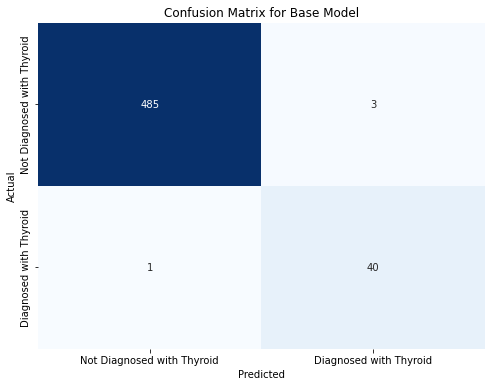

```python
from sklearn.metrics import confusion_matrix

#  Training and testing
X_train, X_test, y_train, y_test = train_test_split(X, y, test_size=0.2, random_state= 15)

# Creating a Decision Tree classifier
dt_classifier = DecisionTreeClassifier(random_state=67, criterion="gini", max_depth=2)
dt_classifier.fit(X_train, y_train)

# Predicting
y_pred = dt_classifier.predict(X_test)


# Confusion matrix for random forest
conf_matrix = confusion_matrix(y_test, y_pred)

# Defining class labels
class_labels = ['Not Diagnosed with Thyroid', 'Diagnosed with Thyroid']

# Plot the confusion matrix
plt.figure(figsize=(8, 6))
sns.heatmap(conf_matrix, annot=True, fmt='d', cmap='Blues', cbar=False,
            xticklabels=class_labels, yticklabels=class_labels)
plt.title('Confusion Matrix for Base Model')
plt.xlabel('Predicted')
plt.ylabel('Actual')
plt.show()
```

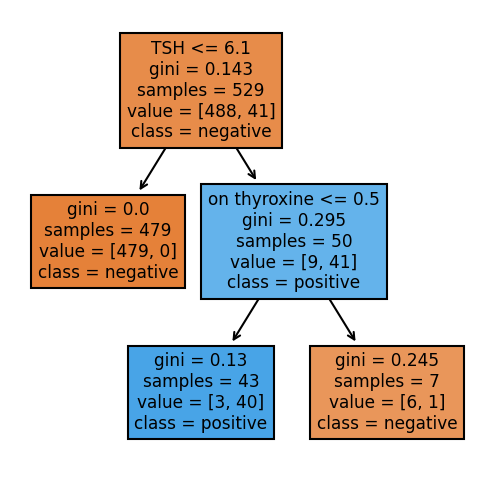

```python
import matplotlib.pyplot as plt
from sklearn.tree import DecisionTreeClassifier
from sklearn import tree


# Train the model on the data
dt_classifier.fit(X_test, y_test)

fn=df_cleaned.columns.tolist()
cn=['negative', 'positive']

# Setting dpi = 150 to make image clearer than default
fig, axes = plt.subplots(nrows = 1,ncols = 1,figsize = (4,4), dpi=150)

tree.plot_tree(dt_classifier,
           feature_names = fn,
           class_names=cn,
           filled = True);

# citation: https://stackoverflow.com/questions/54370065/displaying-scikit-decision-tree-figure-in-jupyter-notebook?fbclid=IwAR03y2L160HDcQneEf7tSWiZ1qQopYWqvkMTZJ0S6Uq29S2oDyz1kmMYYYM
```

```python
# Doing a count to evluate the spread of the dataset
df_cleaned['binaryClass'].value_counts()
```

```
binaryClass
False    2427
True      216
Name: count, dtype: int64
```

# Question 8

**Problems**

1. I think the main problem is that my dataset is highly skewed. With only 216 rows of data where a patient has been diagnosed with thyroid and a substantially more number of rows 2427 where the patient has not been diagnosed. This skewed dataset has led to a biased model performance, wherein the decison tree algorithm has been trained mostly on patient data who haven't been diagnosed, resulting in poor predictive performance for the minority class, that is patients who have been diagnosed with thyriod.
2. Working with this biased dataset has meant that I cannot rely on accuracy to evaluate my model because accuracy in cases of imbalenced dataset. I can only evaluate my model using either precision, recall, or F1 scores.
3. Accuracy of the model was already high with very few attributes because of the simplistic nature of the dataset. This made it hard to evaluate model performance when changing model parameters.

Although real-world data is often imperfect, the way to overcome these challenges is to have a more balanced dataset to begin with to ensure that our training and testing is happening on a balanced dataset that further ensures a more accurate predictive analysis. We can achieve this by oversampling the minority class to ensure that we have a balanced dataset.

# Question 9

Explain how your machine learning solution answers the research question you defined.

> The research question I set out to answer was: How accurately can we predict thyroid disease diagnosis based on a patient's health data? My model answers the question by providing evaluation parameters such as accuracy, recall, precision, and F1 score. As explained in the previous question, accuracy is not the most accurate measure of model performance. Therefore, I rely on recall to answer this question. The recall rate is 0.9756, which indicates that the model has been able to perform well. We can conclude that we have been able to answer the research question. However, as I will go on to analyze this further, the overall performace of my model comes in question given how skewed my dataset is.

> In its current state, there are more risks than advantages in deploying this model to unseen data. Firstly, the small sample size means that our model has not seen enough data, making it hard to make generalized predictions on most population sizes. It will likely yield low accuracy if we test it on data that is more varied, especially for the positive cases. Second, it predicts thyroid disease based on very specific attributes, which limits the usability in real life. For instance, we cannot use a different types of test to predict thyroid. It has to be these specific attributes that need to be deployed to make any sort of prediction.

> There are of course advantages when the model is right. This model provides great early predictive power on the basis of preliminary attributes, which tent to be less invasive tests, till further more invasive procedures can be deployed to concretely diagnose a thyroid patient.

> Positive impacts of my model are the lessened burden on healthcare system to diagonse thyroid disease. On the basis of a few attributes, the hospital will be able to ascertain which person is more or less suseptible to being diagnosed with the disease. This will save millions of dollars in further diagnostic costs for the patients as well as help detect the disease early on. Negative impacts of my model are the lack of generalizability, which would have been highly advantageous to help predict the prevelance of thyroid in different populations around the world.

# Question 10

> Another research question: "What are the key risk factors associated with thyroid disease development, and how do they interact with each other?"

> Understanding the key risk factors for thyroid disease is quite important. If we are able to correctly predict which factors are most closely associated with the disease, we can help patients better by improving prevention and early detection. We can also provide better personalized treatment as we'd be able to understand what factors increase risks of the disease and provide insights to patients to better manage their disease.

# Question 11

[figure not shown]